# Plotting data with Pandas

Pandas makes plotting simple with matplotlib and [DataFrame.plot](https://pandas.pydata.org/pandas-docs/stable/generated/pandas.DataFrame.plot.html)  
The syntax is pretty straightforward and there are plenty of examples in the documentation.

Some things to note about the syntax:

- `df.plot(kind='line') is equivalent to df.plot.line()`

We will be using data from the [iex trading](https://iextrading.com/developer/docs/#stocks) API

This notebook provides quick, simple examples of the following plot types

- Line Plot
  - Customising your plot
  - Set colours, line type and axis limits
- Histogram
- Box Plot
- Scatter Plot
- KDE Plot
- Pie Plot
- Bar Plot

```python
import pandas as pd
import requests

# the following allow plotting directly in the notebook
# you can configure higher resolution plots for retina displays
% matplotlib inline
% config InlineBackend.figure_format = 'retina'
```

```python
url = 'https://api.iextrading.com/1.0/stock/aapl/batch?types=quote,news,chart&range=6m'

# create a request object
r = requests.get(url).json()

# view the first 3 results
r['chart'][0:3]
```

```
[{'change': -3.0288,
  'changeOverTime': 0,
  'changePercent': -1.616,
  'close': 184.3976,
  'date': '2018-06-19',
  'high': 185.0332,
  'label': 'Jun 19, 18',
  'low': 182.1732,
  'open': 183.8515,
  'unadjustedVolume': 33578455,
  'volume': 33578455,
  'vwap': 183.8746},
 {'change': 0.804364,
  'changeOverTime': 0.004362312741597433,
  'changePercent': 0.436,
  'close': 185.202,
  'date': '2018-06-20',
  'high': 185.8971,
  'label': 'Jun 20, 18',
  'low': 184.4373,
  'open': 185.053,
  'unadjustedVolume': 20628701,
  'volume': 20628701,
  'vwap': 185.2062},
 {'change': -1.0328,
  'changeOverTime': -0.0012386278346357105,
  'changePercent': -0.558,
  'close': 184.1692,
  'date': '2018-06-21',
  'high': 187.0391,
  'label': 'Jun 21, 18',
  'low': 183.6528,
  'open': 185.9468,
  'unadjustedVolume': 25711898,
  'volume': 25711898,
  'vwap': 184.86}]
```

```python
# convert the json response into a dataframe
df = pd.DataFrame(r['chart'])

df.head()
```

|  | change | changeOverTime | changePercent | close | date | high | label | low | open | unadjustedVolume | volume | vwap |
| --- | --- | --- | --- | --- | --- | --- | --- | --- | --- | --- | --- | --- |
| 0 | -3.028800 | 0.000000 | -1.616 | 184.3976 | 2018-06-19 | 185.0332 | Jun 19, 18 | 182.1732 | 183.8515 | 33578455 | 33578455 | 183.8746 |
| 1 | 0.804364 | 0.004362 | 0.436 | 185.2020 | 2018-06-20 | 185.8971 | Jun 20, 18 | 184.4373 | 185.0530 | 20628701 | 20628701 | 185.2062 |
| 2 | -1.032800 | -0.001239 | -0.558 | 184.1692 | 2018-06-21 | 187.0391 | Jun 21, 18 | 183.6528 | 185.9468 | 25711898 | 25711898 | 184.8600 |
| 3 | -0.536241 | -0.004146 | -0.291 | 183.6330 | 2018-06-22 | 184.8544 | Jun 22, 18 | 183.4145 | 184.8246 | 27200447 | 27200447 | 184.0014 |
| 4 | -2.730900 | -0.018956 | -1.487 | 180.9021 | 2018-06-25 | 183.6330 | Jun 25, 18 | 179.4721 | 182.1236 | 31663096 | 31663096 | 181.0641 |

# Plotting the data

The `plot` method on Series and DataFrame is just a simple wrapper around `plt.plot()`

**1. Time Series**  
Matplotlib has some annoyances when plotting dates. You can read about that [here](https://matplotlib.org/gallery/recipes/common_date_problems.html). The easiest way to work around these with Pandas is to convert your dates to a datetime objuect using [pd.to_datetime()](https://pandas.pydata.org/pandas-docs/stable/generated/pandas.to_datetime.html) then **set your date as the index**. If the index consists of dates, pandas calls `gcf().autofmt_xdate()` and tries to format the x-axis dates nicely.

```python
# convert date to a datetime object

df.date = pd.to_datetime(df.date)

# set the index to the date
df.index = df.date


df.head()
```

| date | change | changeOverTime | changePercent | close | date | high | label | low | open | unadjustedVolume | volume | vwap |
| --- | --- | --- | --- | --- | --- | --- | --- | --- | --- | --- | --- | --- |
| 2018-06-19 | -3.028800 | 0.000000 | -1.616 | 184.3976 | 2018-06-19 | 185.0332 | Jun 19, 18 | 182.1732 | 183.8515 | 33578455 | 33578455 | 183.8746 |
| 2018-06-20 | 0.804364 | 0.004362 | 0.436 | 185.2020 | 2018-06-20 | 185.8971 | Jun 20, 18 | 184.4373 | 185.0530 | 20628701 | 20628701 | 185.2062 |
| 2018-06-21 | -1.032800 | -0.001239 | -0.558 | 184.1692 | 2018-06-21 | 187.0391 | Jun 21, 18 | 183.6528 | 185.9468 | 25711898 | 25711898 | 184.8600 |
| 2018-06-22 | -0.536241 | -0.004146 | -0.291 | 183.6330 | 2018-06-22 | 184.8544 | Jun 22, 18 | 183.4145 | 184.8246 | 27200447 | 27200447 | 184.0014 |
| 2018-06-25 | -2.730900 | -0.018956 | -1.487 | 180.9021 | 2018-06-25 | 183.6330 | Jun 25, 18 | 179.4721 | 182.1236 | 31663096 | 31663096 | 181.0641 |

As you can see, the index is now a `datetime` index. This is useful when plotting timeseries data and will make your life much much simpler.

Lets plot some data!

# Line Plot

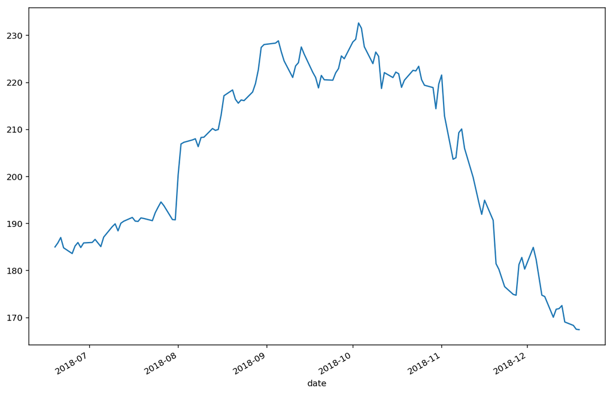

```python
# plot a single variable as a time series
# to adjust the size of the figure, use figsize as a keyword argument

df['high'].plot.line(figsize=(12,8));
```

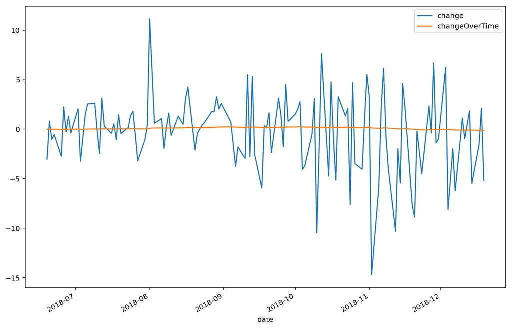

```python
# plot mulitple variables as a time series
# use two sets of square brackets to return a data frame [[ ]]

df[['change', 'changeOverTime']].plot.line(figsize=(12,8));
```

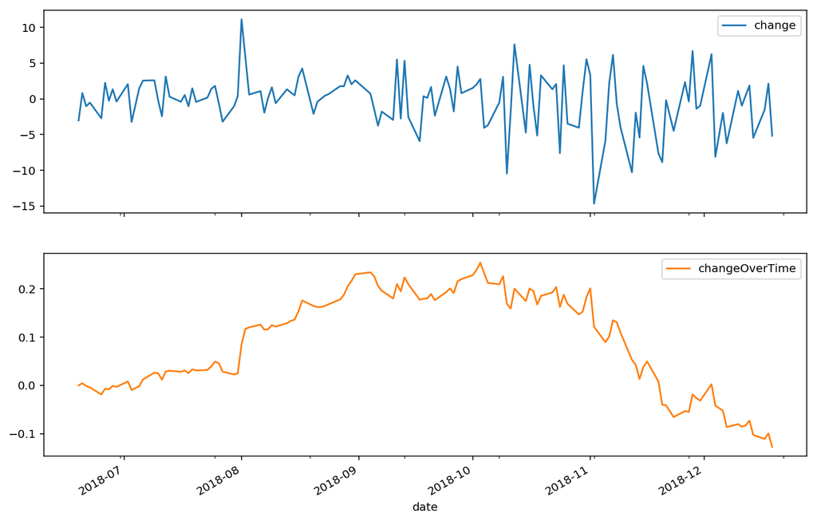

```python
# plot multiple variables on separate axis

df[['change', 'changeOverTime']].plot.line(subplots=True, figsize=(12,8));
```

## Customising your plots

- Adding titles
  - Axis titles can be set in a number of ways
  - e.g. like [this](https://stackoverflow.com/questions/21487329/add-x-and-y-labels-to-a-pandas-plot/21487560) or [this](http://jonathansoma.com/lede/data-studio/matplotlib/labeling-your-axes-in-pandas-and-matplotlib/)
- Setting colours
- adjusting line types
- setting axis limits

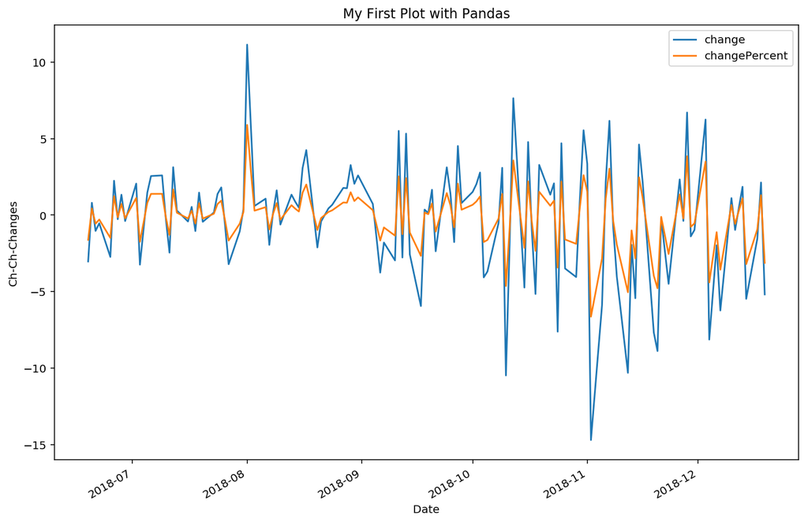

```python
# there are a few ways to set axis labels and titles
# when you create a plot, it returns an ax element
# there are a tonne of methods available to use
# like 'set_xlabel' and 'set_ylabel'
# or you can set both using 'set'

# set an axis object
ax = df[['change', 'changePercent']].plot.line(figsize=(12,8))

# Set the title
ax.set_title("My First Plot with Pandas")

# Set the y label
ax.set_ylabel("Ch-Ch-Changes")

# Set the x label
ax.set_xlabel("Date");
```

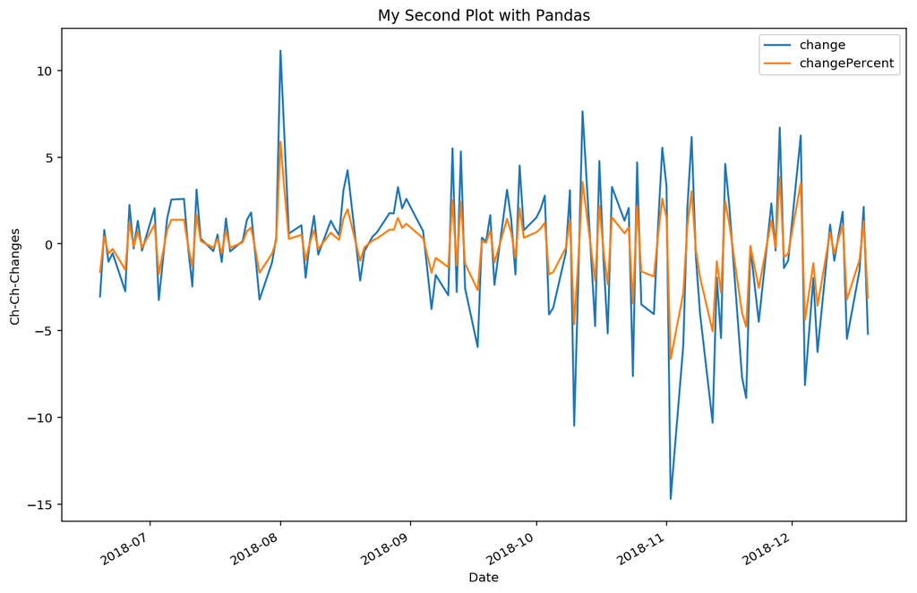

```python
# here is another way to do the same thing
# using 'set'

# set an axis object
ax = df[['change', 'changePercent']].plot.line(figsize=(12,8))

ax.set(title="My Second Plot with Pandas",
      ylabel='Ch-Ch-Changes', xlabel='Date');
```

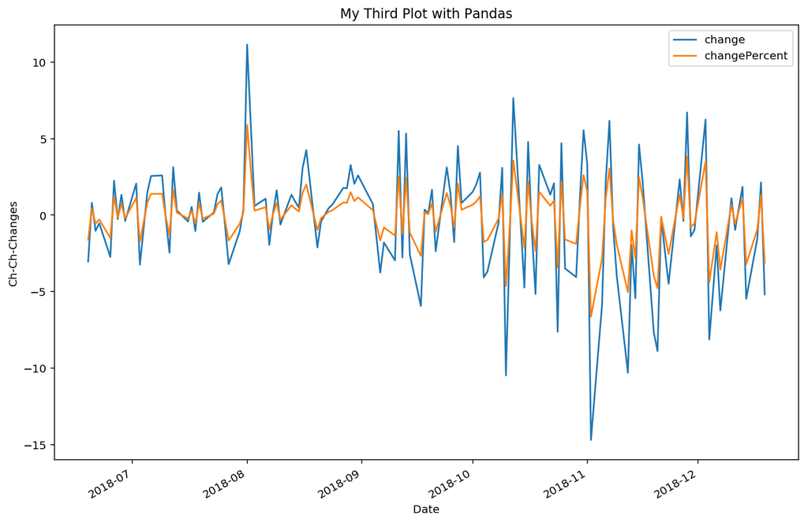

```python
# and finally, a third way

df[['change', 'changePercent']].plot.line(figsize=(12,8), title='My Third Plot with Pandas').set(ylabel='Ch-Ch-Changes', xlabel='Date');
```

## Set colours, line type and limit axis

- Colours can be set using the `color` argument. You can supply [hex](https://www.color-hex.com) colour codes, or by using [abbreviations](https://matplotlib.org/2.1.1/api/_as_gen/matplotlib.pyplot.plot.html)
- Line style can be controlled using the `marker` and `linewidth` arguments
- More info on styling can be found [here](https://matplotlib.org/2.1.1/api/_as_gen/matplotlib.pyplot.plot.html) and [here](https://matplotlib.org/tutorials/introductory/customizing.html)
- **axis limits** can be specified using `ax.set()` and `xlim` or `ylim`

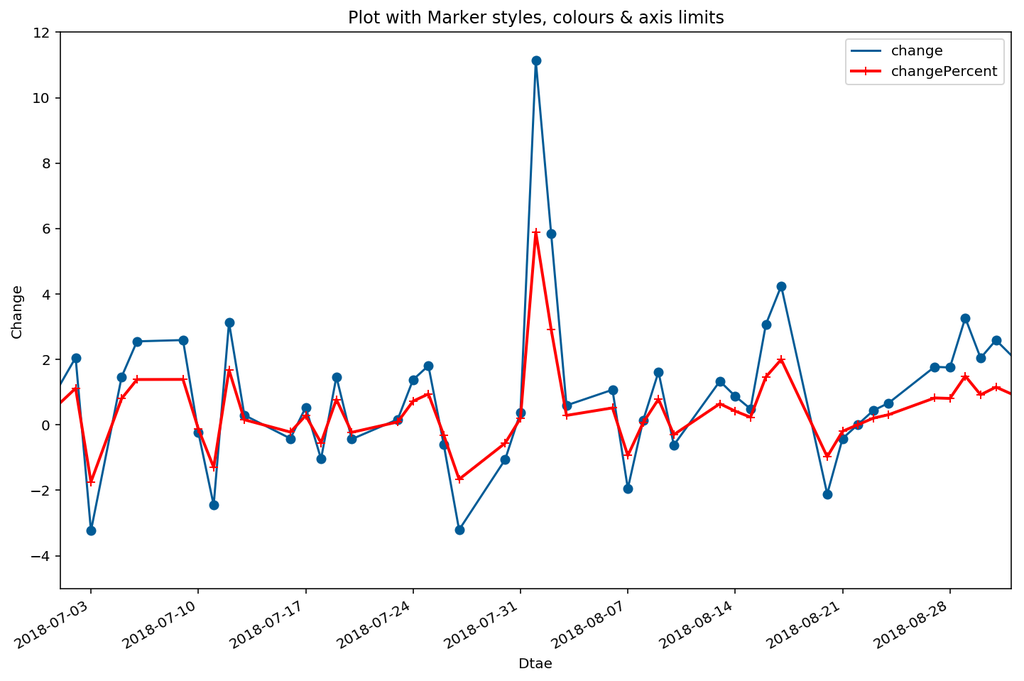

```python
# to specify different line and marker options the easiest way is to split out your plot
# so that lines can be controlled individually

fig, ax = plt.subplots(figsize=(12,8))

df.plot(kind='line', y='change', ax=ax, color='#005b96', marker='o')
df.plot(kind='line', y='changePercent', ax=ax, color='r', marker='+', linewidth=2)

ax.set(title="Plot with Marker styles, colours & axis limits",
       xlabel='Dtae', ylabel='Change',
       ylim=(-5, 12),
       xlim=('2018-07-01', '2018-09-01'));
```

## Bar Plots, Histograms, Scatter Plots, Pie Charts

"Plotting methods allow for a handful of plot styles other than the default line plot. These methods can be provided as the kind keyword argument to plot()" - Pandas [Docs](https://pandas.pydata.org/pandas-docs/stable/visualization.html)

You can also use the following syntax `df.plot.line()` or `df.plot.bar()`

```python
# lets take a look at the data again

df.head()
```

| date | change | changeOverTime | changePercent | close | date | high | label | low | open | unadjustedVolume | volume | vwap |
| --- | --- | --- | --- | --- | --- | --- | --- | --- | --- | --- | --- | --- |
| 2018-06-19 | -3.028800 | 0.000000 | -1.616 | 184.3976 | 2018-06-19 | 185.0332 | Jun 19, 18 | 182.1732 | 183.8515 | 33578455 | 33578455 | 183.8746 |
| 2018-06-20 | 0.804364 | 0.004362 | 0.436 | 185.2020 | 2018-06-20 | 185.8971 | Jun 20, 18 | 184.4373 | 185.0530 | 20628701 | 20628701 | 185.2062 |
| 2018-06-21 | -1.032800 | -0.001239 | -0.558 | 184.1692 | 2018-06-21 | 187.0391 | Jun 21, 18 | 183.6528 | 185.9468 | 25711898 | 25711898 | 184.8600 |
| 2018-06-22 | -0.536241 | -0.004146 | -0.291 | 183.6330 | 2018-06-22 | 184.8544 | Jun 22, 18 | 183.4145 | 184.8246 | 27200447 | 27200447 | 184.0014 |
| 2018-06-25 | -2.730900 | -0.018956 | -1.487 | 180.9021 | 2018-06-25 | 183.6330 | Jun 25, 18 | 179.4721 | 182.1236 | 31663096 | 31663096 | 181.0641 |

## Histogram

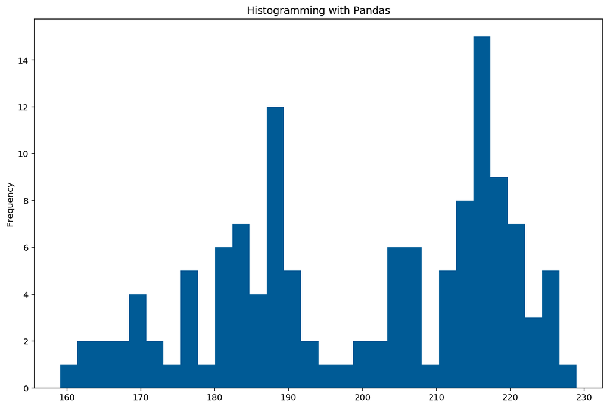

```python
# Histogram

ax = df['low'].plot.hist(bins=30, figsize=(12,8), color='#005b96')
ax.set(title='Histogramming with Pandas');
```

# Box Plot

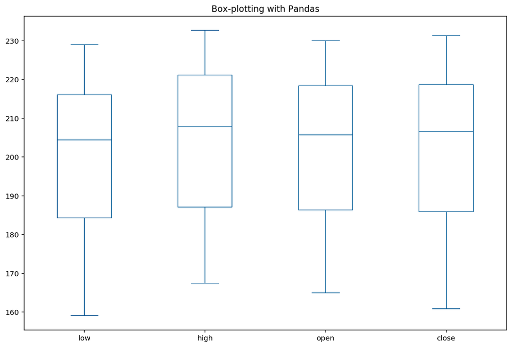

```python
# Box PLot

ax = df[['low', 'high', 'open', 'close']].plot.box( figsize=(12,8), color='#005b96')
ax.set(title='Box-plotting with Pandas');
```

# Scatter Plot

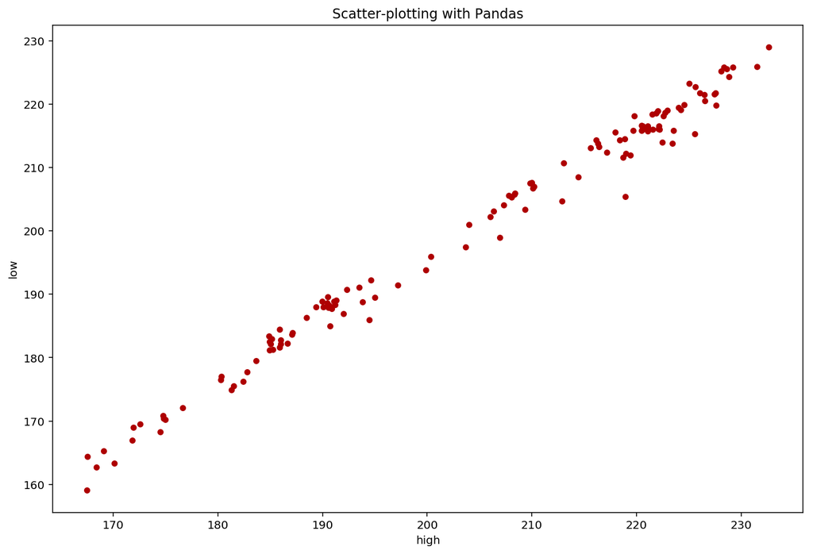

```python
# scatter plot

ax = df.plot.scatter(x='high', y='low', figsize=(12,8), color='#ae0001')
ax.set(title='Scatter-plotting with Pandas');
```

# KDE Plot

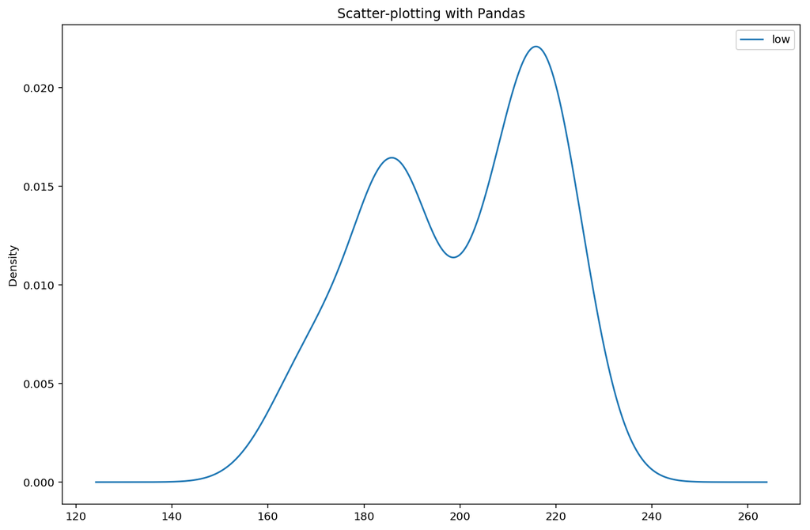

```python
# kde plot

ax = df.plot.kde(y='low', figsize=(12,8))
ax.set(title='Scatter-plotting with Pandas');
```

# Pie Plot

[figure not shown]

```python
# Pie Plot

# create some data
data = {'a': 25, 'b': 45, 'c': 15}

df2 = pd.DataFrame(data, index=['blue', 'organe', 'green'])


# create the plot
ax = df2.plot.pie(y='a', figsize=(10,10))
ax.set(title='Pie-plotting with Pandas');
```

# Bar Plot

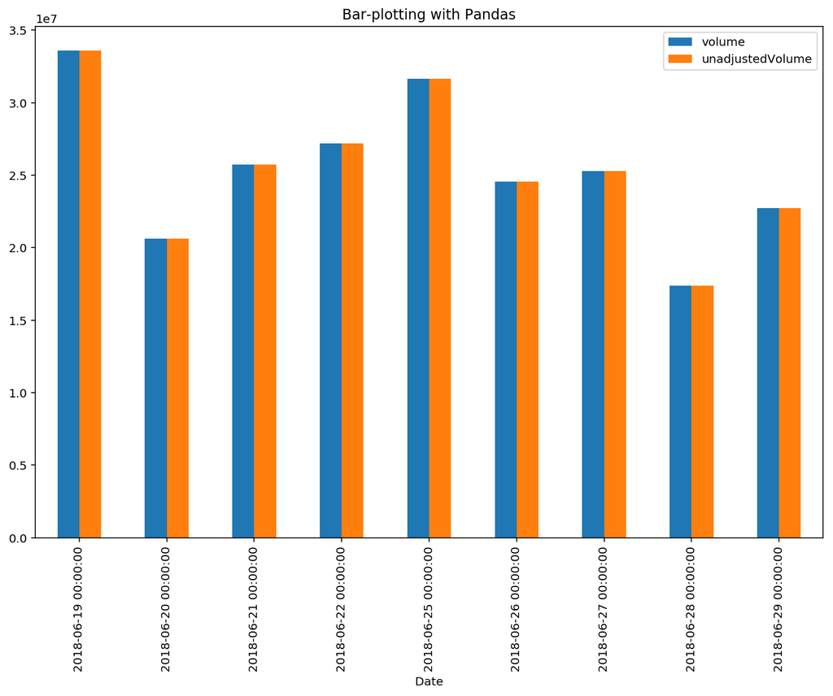

```python
# bar plot
# will use one month worht of data

df_sub = df[df['date'] < '2018-07-01']

ax = df_sub[['volume', 'unadjustedVolume']].plot.bar(figsize=(12, 8))

ax.xaxis.set_minor_locator(months)

ax.set(title='Bar-plotting with Pandas', xlabel='Date');
```